# Assortativity Tutorial: Trade Networks

Muhammed Cifci

3/2/2020

```r
# network packages
library(sna)
library(statnet)
library(network)

# visualization packages
library(ggplot2)
library(ggnetwork)
library(GGally)

# data manipulation packages
library(readr)
library(dplyr)
library(data.table)
```

Assortativity is a network property, which refers to the extent to which actors form ties with similar versus dissimilar actors. Homophily considers likelihood of nodes forming ties based on similarity by various node/vertex characteristics. Heterophily is the opposite of homophily and defines a process in which actors who are different from each other are more likely to form ties. This process is the basis for commonly used phrase “birds of a feather, flock together”.

We can think of assortivity as another type of clustering, where clustering occurs based on similarity/dissimilarity of node characteristics. So it is preferential attachment of nodes to other nodes that are similar/dissimilar in numerical or categorical attributes.

A classic example of study of social interactions of homophily is by race. People who belong to same race tend to be more likely to form ties with people of same race. An example of heterophily can be formal academic advising relationships where students are more likely to form ties to faculty for advising than to other students.

We will use the replication data from “Persistent Patterns of International Commerce” by Michael Ward and Peter Hoff (2007). The replication data includes dyadic trade relationships for countries for 1981-2001, polity scores for each country and degree of cooperation in conflict episodes.

# 1) Prepare the data

```r
YX<-dget("YX") # Read in the data (data format is list of data frames)
country_codes <- read_csv("countryContinent.csv") # read in data for region variables
```

```r
# create a network object from edgelist for only 1981
YX_1981 <- YX[[1]][1:9] # Edgelist for only 1981.
YX_1981$exp <- as.character(YX_1981$exp) # Change class of variable to character
YX_1981$imp <- as.character(YX_1981$imp) # Change class of variable to character
YX_1981 <- YX_1981[YX_1981$ltrade != 0,] # Use 3rd column (trade) to remove any dyad where trade did not occur

# add regional variables to the data to use 'assortativity_nominal'
setnames(country_codes, "country", "exp") # rename column to merge 'by'
# only keep variables we want to join
country_codes <- country_codes %>% select("exp", "continent","sub_region")
# join the two data frame
YX_1981 <- YX_1981 %>% left_join(country_codes, by = "exp")

# add polity scores as categorical variables
YX_1981$polity_cat[YX_1981$pty.exp < -5] <- "autocracy"
YX_1981$polity_cat[YX_1981$pty.exp > -6 & YX_1981$pty.exp < 6] <- "anocracy"
YX_1981$polity_cat[YX_1981$pty.exp > 5] <- "democracy"

# create a matrix from YX_el; 1st column exporter, 2nd column importer
YX_1981_el <- as.matrix(YX_1981[1:2])
YX_1981_node_list <- YX_1981  %>% select(exp, lgdp.exp, pty.exp,continent, sub_region, polity_cat) # Create a nodelist
YX_1981_node_list <- YX_1981_node_list[!duplicated(YX_1981_node_list),] # Remove duplicates

# create a network object
YX_1981_net1 <- network(YX_1981_el[,1:2], matrix.type = 'edgelist', directed = TRUE)

network.vertex.names(YX_1981_net1) # check node names; 82 countries

# set vertix attributes
set.vertex.attribute(YX_1981_net1, 'lgdp.exp', YX_1981_node_list$lgdp.exp) # lgdp.exp = log GDP of exporter
set.vertex.attribute(YX_1981_net1, 'pty.exp', YX_1981_node_list$pty.exp) # pty.exp = Polity of exporter
set.vertex.attribute(YX_1981_net1, 'continent', YX_1981_node_list$continent) # continent
set.vertex.attribute(YX_1981_net1, 'sub_region', YX_1981_node_list$sub_region) # sub-region
set.vertex.attribute(YX_1981_net1, 'polity_cat', YX_1981_node_list$polity_cat) # categorical polity score

# set edge weights
set.edge.attribute(YX_1981_net1, 'weight', YX_1981$ltrade) # ltrade = log trade (volume of trade)
# set.edge.value(YX_1981_net1, 'ltrade', YX_1981$ltrade) # ltrade = log trade (volume of trade)

####  set.edge value vs. set.edge.attribute
# set.edge.value is a convenience function which allows edge attributes to be given in adjacency matrix form, and the assignment form of network.vertex.names is likewise a convenient frontend to set.vertex.attribute for vertex names.
# When edges are removed, the remaining edge ids are NOT permuted and NULL elements will be left on the list of edges, which may complicate some functions that require eids (such as set.edge.attribute)

# use these to see if the edge attribute is set.
# get.edge.attribute(YX_1981_net1, 'ltrade')
# list.edge.attributes(YX_1981_net1)s

# make sure the weights are recorded correctly
head(YX_1981[1:3],5) # This is the original data
head(as.edgelist(YX_1981_net1, 'weight'),5) # This is edgelist extracted from the network
# get.vertex.attribute(YX_1981_net1, 'vertex.names') # Use this to see if the ids make sense

# look at a summary of the network object
summary.network(YX_1981_net1, # the network we want to look at
                print.adj = FALSE # if TRUE then this will print out the whole adjacency matrix.
                )
```

[output not shown]

In **Figure 1**, I illustrate histograms of the two node attributes provided in the data, log(GDP) and polity score, for 1981. Left plot indicate that there is a right skewed distribution for log(GDP); there ar few countries that have very strong economies. The maximum log(GDP) value is 28.76, mean is 23.71 and minimum value is 20.16.

Polity score captures thee regime authority spectrum. The range is interpreted as following: -10 to -6 is autocracy, -5 to 5 is anocracy, and 6-10 is demcocracy. Right plot suggests that the most countries fall in either democracy or autocracy categories. There are not many countries in the middle (-5 to 5 range). The maximum polity distribution is a 10 (full democracy), mean is 1.31 (anocracy) and the minimum value is -10 (autocracy).

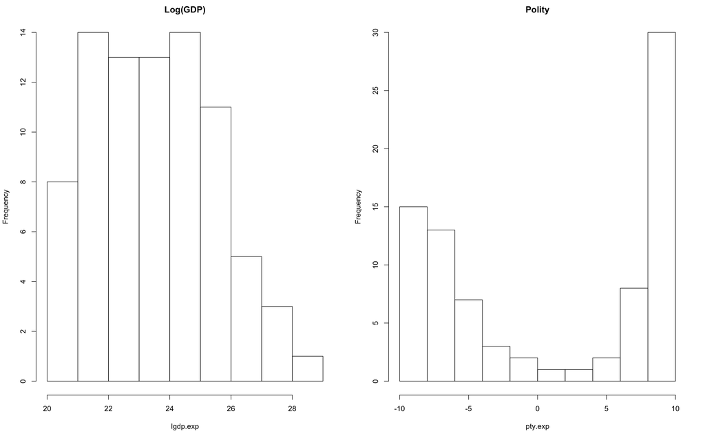

# 2) Visualize the network

```r
YX_1981_node_list$significant_countries <- ifelse(YX_1981_node_list$lgdp.exp >= 25, YX_1981_node_list$exp, NA) # vector of just those 20 countries as labels
set.vertex.attribute(YX_1981_net1, 'significant_countries', YX_1981_node_list$significant_countries)

set.seed(123)
YX_1981_net1_fr <- ggnetwork(YX_1981_net1, layout = 'fruchtermanreingold') # weights already defined, but we could have added weight by specifying 'weights="ltrade"'
YX_1981_net1_kk <- ggnetwork(YX_1981_net1, layout = 'kamadakawai') #layout for kamadakawai (minimal difference from FR layout)
YX_1981_net1_cir <- ggnetwork(YX_1981_net1, layout = 'circle') #layout for circle (not helpful in this case)

head(YX_1981_net1_fr,5) # show the network
```

|  | x | y | continent | lgdp.exp | polity_cat | pty.exp | significant_countries | sub_region | vertex.names | xend | yend | weight |
| --- | --- | --- | --- | --- | --- | --- | --- | --- | --- | --- | --- | --- |
| 1 | 0 | 0.6032144 | Americas | 20.16115 | autocracy | -7 | NA | South America | Guyana | 0.4008796 | 0.3989394 | 7.81440 |
| 2 | 0 | 0.6032144 | Americas | 20.16115 | autocracy | -7 | NA | South America | Guyana | 0.3675426 | 0.2477305 | 12.63156 |
| 3 | 0 | 0.6032144 | Americas | 20.16115 | autocracy | -7 | NA | South America | Guyana | 0.1094093 | 0.5431600 | 15.46483 |
| 4 | 0 | 0.6032144 | Americas | 20.16115 | autocracy | -7 | NA | South America | Guyana | 0.2282081 | 0.4804439 | 14.05963 |
| 5 | 0 | 0.6032144 | Americas | 20.16115 | autocracy | -7 | NA | South America | Guyana | 0.6715278 | 0.6584478 | 15.10554 |

```r
(.119+.067+.083+.073+.085)/2
```

```
[1] 0.2135
```